# Environment Setup

```python
import numpy as np
import pandas as pd
import matplotlib.pyplot as plt
import scipy.stats as stats
import statsmodels.api as sm
from scipy.stats import shapiro
import seaborn as sns
from google.colab import files
from statsmodels.graphics.tsaplots import plot_acf
from statsmodels.tsa.stattools import adfuller
from scipy.stats import shapiro, normaltest, probplot
from sklearn.linear_model import RidgeCV
from sklearn.linear_model import LassoCV
from sklearn.linear_model import ElasticNetCV
from sklearn.metrics import mean_squared_error, mean_absolute_error
from statsmodels.stats.stattools import durbin_watson
from sklearn.linear_model import RidgeCV, LassoCV, ElasticNetCV
from sklearn.ensemble import StackingRegressor
import statsmodels.api as sm
import seaborn as sns
```

# Read Data

```python
file_name = "InvestmentReplica.xlsx"

#Futures and hedge founds
df = pd.read_excel(file_name, sheet_name ='Replica')
found_index=['MXWO','MXWD','LEGATRUU','HFRXGL']
futures=df.drop(columns=found_index)
found_index=['Date','MXWO','MXWD','LEGATRUU','HFRXGL']
hedge_fd=df.loc[:,found_index]


print(futures.head())
print(hedge_fd.head())
```

```
        Date     RX1         TY1    GC1    CO1      ES1     VG1      NQ1  \
0 2007-10-23  113.70  110.515625  759.0  82.85  1525.50  4393.0  2212.00
1 2007-10-30  113.79  110.656250  787.8  87.44  1536.00  4476.0  2217.75
2 2007-11-06  113.79  110.875000  823.4  93.26  1525.00  4425.0  2233.50
3 2007-11-13  114.35  111.718750  799.0  88.83  1483.25  4323.0  2066.75
4 2007-11-20  114.72  113.156250  791.4  95.49  1446.00  4296.0  2035.50

     LLL1     TP1      DU1         TU2
0  1287.0  1570.5  103.385  103.718750
1  1323.9  1610.5  103.410  103.812500
2  1320.0  1575.5  103.410  104.046875
3  1271.0  1440.5  103.595  104.304688
4  1225.2  1472.5  103.800  104.945312
        Date     MXWO    MXWD  LEGATRUU   HFRXGL
0 2007-10-23  1633.44  414.14  350.2138  1343.63
1 2007-10-30  1663.89  423.26  352.5413  1356.53
2 2007-11-06  1651.59  419.51  354.1758  1360.20
3 2007-11-13  1601.81  405.98  357.2217  1347.16
4 2007-11-20  1570.74  398.54  359.4446  1335.21
```

# Creation of the Monster Index

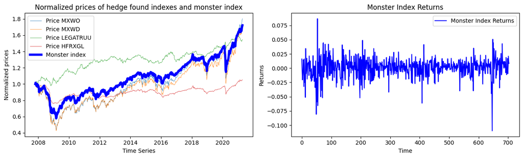

```python
#Creation of a monster index
#Computing returns and prices of our hedge found index
dates=hedge_fd.iloc[:,0]
#Getting the notmalized prices of the hedge founds
prices_hf=hedge_fd.iloc[:,1:]/hedge_fd.iloc[0,1:] #normalized prices
initial_price=hedge_fd.iloc[0,1:]

#Calculate the returns
returns = (hedge_fd.iloc[1:, 1:].values/ hedge_fd.iloc[:-1, 1:].values) - 1
returns = pd.DataFrame(returns, columns=hedge_fd.columns[1:])

#Creation of a Monster index
w_MXWO=0.25
w_LEGATRUU=0.25
w_HFRXGL=0.5

#Computing normalized prices and prices of our Monster Index
y_price=w_MXWO*hedge_fd.iloc[:,1]+w_LEGATRUU*hedge_fd.iloc[:,2]+w_HFRXGL*hedge_fd.iloc[:,3]
y_values = pd.DataFrame(y_price, columns=['Target'])
y_price=y_values/y_values.iloc[0]
#Computing returns of our monster index
returns_MI = (y_price.iloc[1:].values/ y_price.iloc[:-1].values) - 1
returns_MI = pd.DataFrame(returns_MI, columns=['Target'])
returns_MI['Target'] = pd.to_numeric(returns_MI['Target'] , errors='coerce')

#Plot
fig, (ax1, ax2) = plt.subplots(1, 2, figsize=(13, 4))

#Plot of the Normalized Prices
ax1.plot(dates,prices_hf,label=('Price MXWO', 'Price MXWD','Price LEGATRUU','Price HFRXGL'),linewidth=0.5)
ax1.plot(dates,y_price, label=('Monster index'), linewidth=4,c='b')
ax1.set_xlabel('Time Series')
ax1.set_ylabel('Normalized prices')
ax1.set_title('Normalized prices of hedge found indexes and monster index')

ax1.legend()

# Plot Monster Index returns
ax2.plot(returns_MI['Target'], label='Monster Index Returns', color='blue')
ax2.set_xlabel('Time')
ax2.set_ylabel('Returns')
ax2.set_title('Monster Index Returns')
ax2.legend()
plt.tight_layout()
plt.show()
```

# Data Exploration of the Monster Index

In this section, we explore the dataset in relation to the target variable: the Monster Index. Specifically, we examine the following statistical properties of its returns:

- **Gaussianity**
- **Stationarity**
- **Autocorrelation**

All this analysis has been done with respect to the *returns*

**Gaussianity**

```
Shapiro-Wilk Statistic: 0.9404932856559753
p-value: 3.58312750850241e-16
The data does not appear to be normally distributed according to Shapiro-Wilk test.
D'Agostino's K^2 Statistic: 140.70264669863133
p-value: 2.79774723242161e-31
The data does not appear to be normally distributed according to D'Agostino's K^2 test.
```

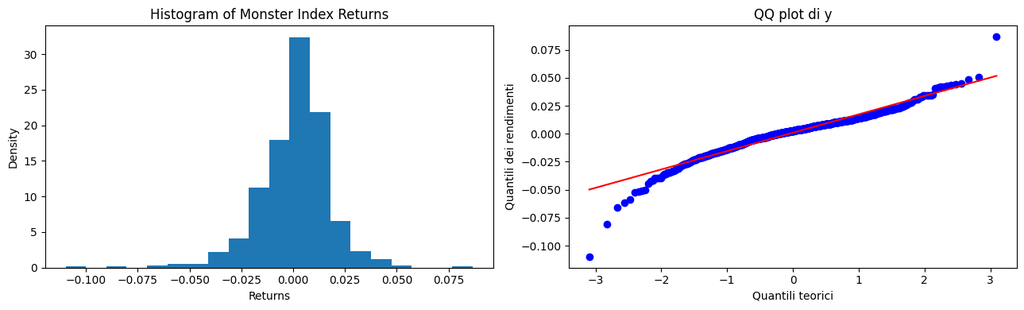

```python
# GAUSSIANITY STUDY

# Perform Shapiro-Wilk test
stat_sw, p_sw = shapiro(returns_MI['Target'])
print('Shapiro-Wilk Statistic:', stat_sw)
print('p-value:', p_sw)
if p_sw > 0.05:
    print('The data appears to be normally distributed according to Shapiro-Wilk test.')
else:
    print('The data does not appear to be normally distributed according to Shapiro-Wilk test.')

# Perform D'Agostino's K^2 test
stat_k2, p_k2 = normaltest(returns_MI['Target'])
print("D'Agostino's K^2 Statistic:", stat_k2)
print('p-value:', p_k2)
if p_k2 > 0.05:
    print("The data appears to be normally distributed according to D'Agostino's K^2 test.")
else:
    print("The data does not appear to be normally distributed according to D'Agostino's K^2 test.")

#Plot
fig, (ax1, ax2) = plt.subplots(1, 2, figsize=(13, 4))

# Plot histogram
ax1.hist(returns_MI['Target'], bins=20, density=True)
ax1.set_xlabel('Returns')
ax1.set_ylabel('Density')
ax1.set_title('Histogram of Monster Index Returns')


# Q-Q plot
stats.probplot(returns_MI['Target'] , dist="norm", plot=plt)
ax2.set_title('QQ plot di y')
ax2.set_xlabel('Quantili teorici')
ax2.set_ylabel('Quantili dei rendimenti')

plt.tight_layout()
plt.show()
```

**Autocorrelation**

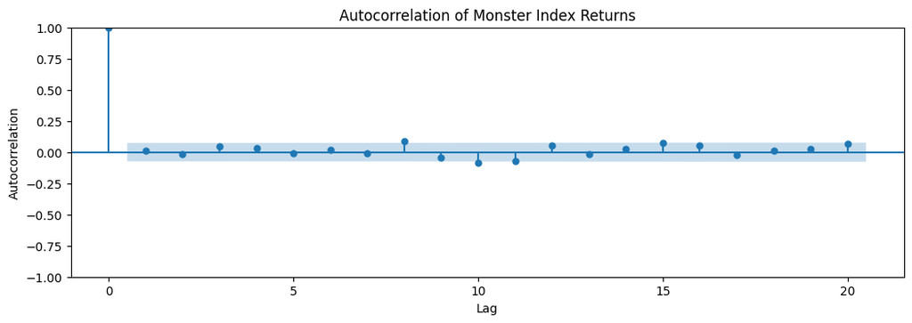

```python
# AUTOCORRELATION STUDY

# Plot autocorrelation
plot_acf(returns_MI['Target'], lags=20, alpha=0.05)
plt.xlabel('Lag')
plt.ylabel('Autocorrelation')
plt.title('Autocorrelation of Monster Index Returns')
plt.subplots_adjust(left=0.3, right=1.8, top=0.9, bottom=0.3)
plt.show()
```

**Stationarity**

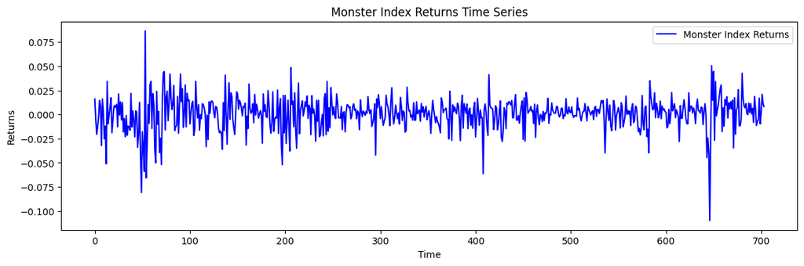

```
ADF Statistic: -7.874720886756821
p-value: 4.878580028148039e-12
Critical Values:
   1%: -3.439835148993393
   5%: -2.865725696693157
   10%: -2.568998987353403
The time series appears to be stationary (reject the null hypothesis of non-stationarity).
```

```python
# STATIONARITY STUDY


# Plot time series
plt.figure(figsize=(14, 4))
plt.plot(returns_MI['Target'], label='Monster Index Returns',c='b')
plt.xlabel('Time')
plt.ylabel('Returns')
plt.title('Monster Index Returns Time Series')
plt.legend()
plt.show()

# Perform Augmented Dickey-Fuller test
result = adfuller(returns_MI['Target'])
print('ADF Statistic:', result[0])
print('p-value:', result[1])
print('Critical Values:')
for key, value in result[4].items():
    print(f'   {key}: {value}')

# Print stationarity result
if result[1] <= 0.05:
    print('The time series appears to be stationary (reject the null hypothesis of non-stationarity).')
else:
    print('The time series does not appear to be stationary (fail to reject the null hypothesis of non-stationarity).')
```

# Futures Data

We used the Futures instruments to replicate our Monster Index so first of all we analyzed what they look like.

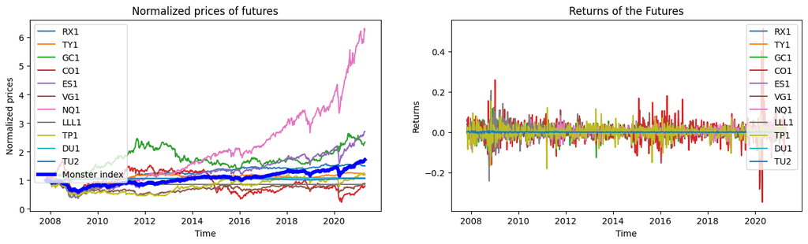

```python
#Futures Prices & Returns
returns_futures = (futures.iloc[1:, 1:].values/ futures.iloc[:-1, 1:].values) - 1
returns_futures = pd.DataFrame(returns_futures, columns=futures.columns[1:])
price_futures=futures.iloc[:,1:]
price_futures_std=futures.iloc[:,1:]/futures.iloc[0,1:] #normalized pricesof futures

#Plot
fig, (ax1, ax2) = plt.subplots(1, 2, figsize=(16, 4))

#Plot Prices
ax1.plot(dates, price_futures_std,label=('RX1', 'TY1', 'GC1', 'CO1','ES1','VG1','NQ1' ,'LLL1', 'TP1', 'DU1','TU2'))
ax1.plot(dates,y_price, label=('Monster index'), linewidth=4,c='b')
ax1.set_xlabel('Time')
ax1.set_ylabel('Normalized prices')
ax1.set_title('Normalized prices of futures')
ax1.legend()

#Plot Returns
ax2.plot(dates[1:] , returns_futures,label=('RX1', 'TY1', 'GC1', 'CO1','ES1','VG1','NQ1' ,'LLL1', 'TP1', 'DU1','TU2'))
ax2.legend()
ax2.set_xlabel('Time')
ax2.set_ylabel('Returns')
ax2.set_title('Returns of the Futures')

plt.show()
```

# Data Exploration of the Futures

As before we proceed to study our datas of the Futures instruments, in particular we check on the *returns* for the:

- **Gaussianity**
- **Autocorrelation**
- **Stationarity**

**Gaussianity**

```
RX1 - Shapiro-Wilk Statistic: 0.9710031747817993, p-value: 1.365562524169306e-10
The data for RX1 does not appear to be normally distributed according to Shapiro-Wilk test.
RX1 - D'Agostino's K^2 Statistic: 56.23708703714871, p-value: 6.141461175716773e-13
The data for RX1 does not appear to be normally distributed according to D'Agostino's K^2 test.
```

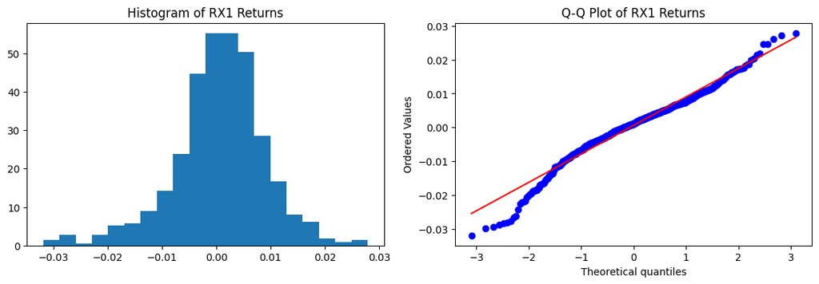

```
TY1 - Shapiro-Wilk Statistic: 0.9643561244010925, p-value: 4.648914499888468e-12
The data for TY1 does not appear to be normally distributed according to Shapiro-Wilk test.
TY1 - D'Agostino's K^2 Statistic: 74.06289423684433, p-value: 8.268883240366154e-17
The data for TY1 does not appear to be normally distributed according to D'Agostino's K^2 test.
```

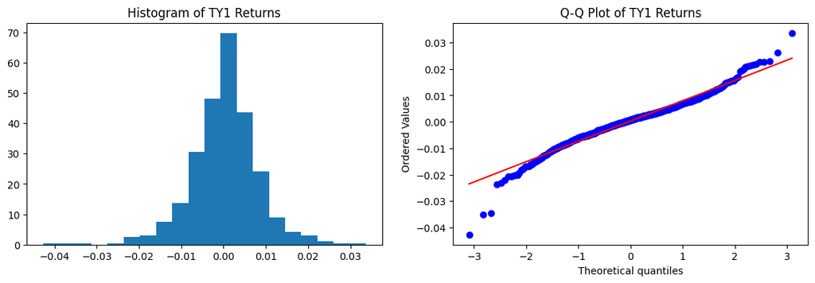

```
GC1 - Shapiro-Wilk Statistic: 0.967229425907135, p-value: 1.897398904660008e-11
The data for GC1 does not appear to be normally distributed according to Shapiro-Wilk test.
GC1 - D'Agostino's K^2 Statistic: 62.38695743051075, p-value: 2.836901928972745e-14
The data for GC1 does not appear to be normally distributed according to D'Agostino's K^2 test.
```

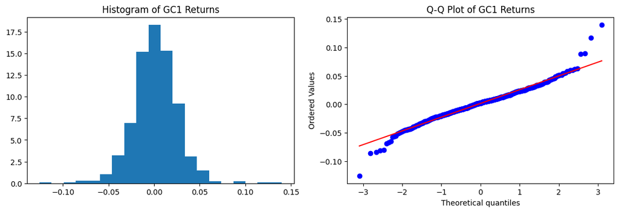

```
CO1 - Shapiro-Wilk Statistic: 0.8655098080635071, p-value: 4.258083811918032e-24
The data for CO1 does not appear to be normally distributed according to Shapiro-Wilk test.
CO1 - D'Agostino's K^2 Statistic: 267.02419554479, p-value: 1.038562578702638e-58
The data for CO1 does not appear to be normally distributed according to D'Agostino's K^2 test.
```

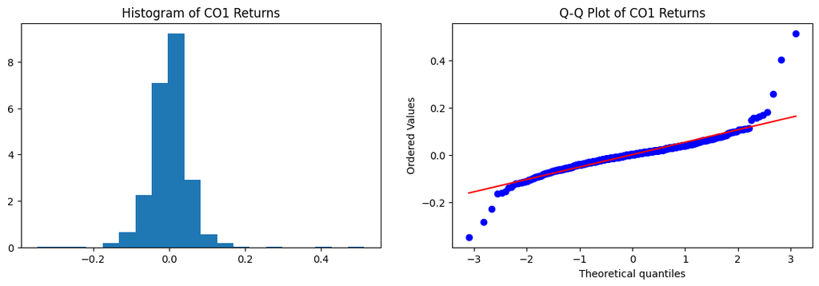

```
ES1 - Shapiro-Wilk Statistic: 0.9259249567985535, p-value: 3.915271659520707e-18
The data for ES1 does not appear to be normally distributed according to Shapiro-Wilk test.
ES1 - D'Agostino's K^2 Statistic: 177.00213921338067, p-value: 3.668375863382302e-39
The data for ES1 does not appear to be normally distributed according to D'Agostino's K^2 test.
```

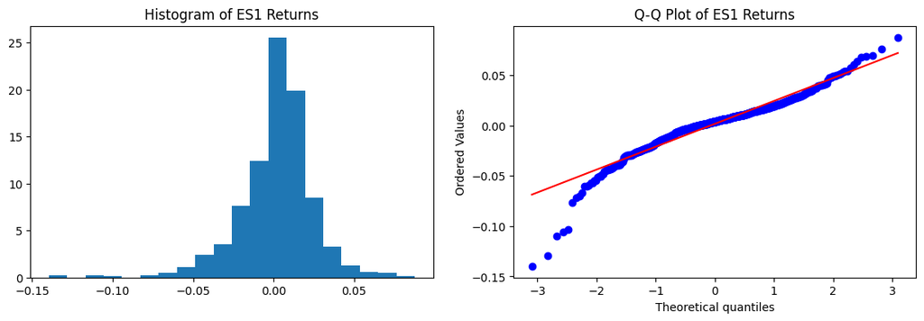

```
VG1 - Shapiro-Wilk Statistic: 0.9586048126220703, p-value: 3.4347023380836006e-13
The data for VG1 does not appear to be normally distributed according to Shapiro-Wilk test.
VG1 - D'Agostino's K^2 Statistic: 65.19411943413161, p-value: 6.970707163786328e-15
The data for VG1 does not appear to be normally distributed according to D'Agostino's K^2 test.
```

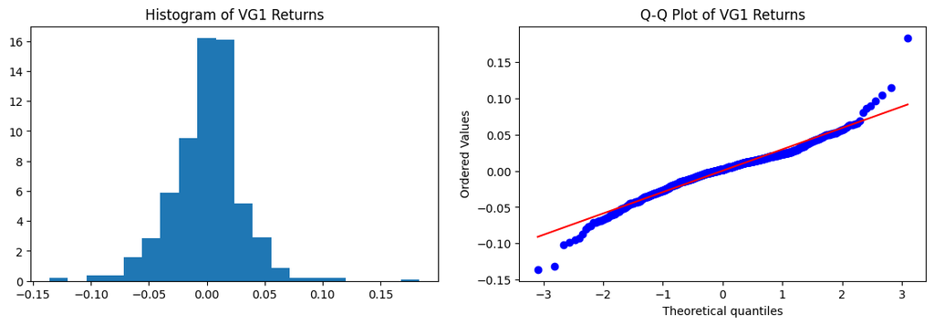

```
NQ1 - Shapiro-Wilk Statistic: 0.9491785168647766, p-value: 7.791714627290117e-15
The data for NQ1 does not appear to be normally distributed according to Shapiro-Wilk test.
NQ1 - D'Agostino's K^2 Statistic: 147.30052436315265, p-value: 1.0329933930519246e-32
The data for NQ1 does not appear to be normally distributed according to D'Agostino's K^2 test.
```

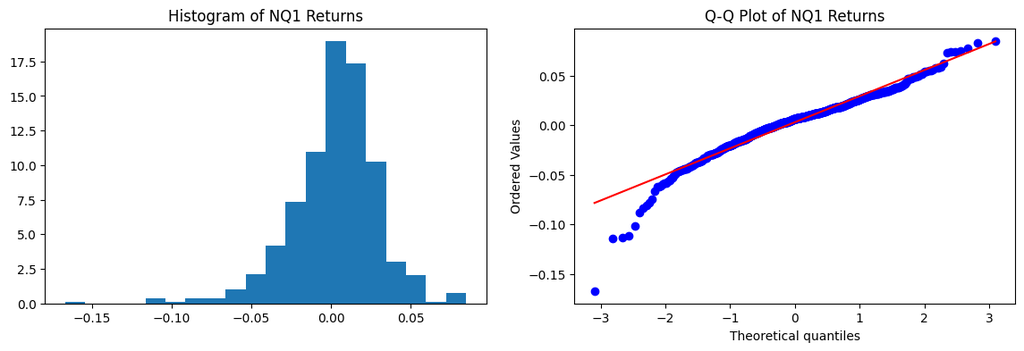

```
LLL1 - Shapiro-Wilk Statistic: 0.5526747703552246, p-value: 6.954022101925907e-39
The data for LLL1 does not appear to be normally distributed according to Shapiro-Wilk test.
LLL1 - D'Agostino's K^2 Statistic: 242.85187768757757, p-value: 1.8424037131238075e-53
The data for LLL1 does not appear to be normally distributed according to D'Agostino's K^2 test.
```

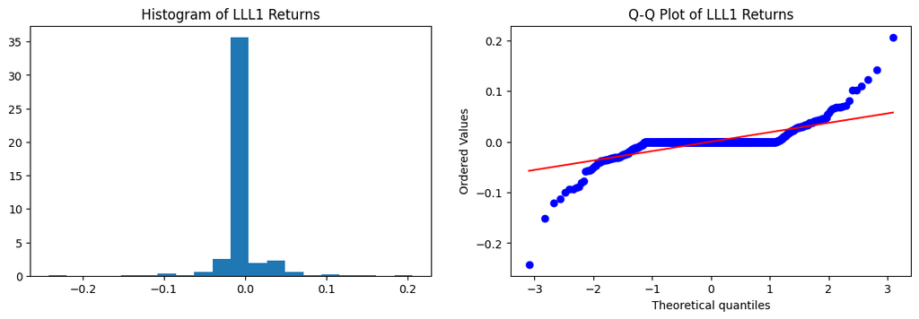

```
TP1 - Shapiro-Wilk Statistic: 0.9319756031036377, p-value: 2.3472641198982474e-17
The data for TP1 does not appear to be normally distributed according to Shapiro-Wilk test.
TP1 - D'Agostino's K^2 Statistic: 132.60489475080806, p-value: 1.6040317787290768e-29
The data for TP1 does not appear to be normally distributed according to D'Agostino's K^2 test.
```

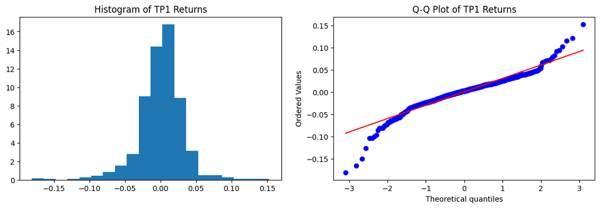

```
DU1 - Shapiro-Wilk Statistic: 0.8974368572235107, p-value: 2.8306629471511783e-21
The data for DU1 does not appear to be normally distributed according to Shapiro-Wilk test.
DU1 - D'Agostino's K^2 Statistic: 93.62374973703983, p-value: 4.675855236765567e-21
The data for DU1 does not appear to be normally distributed according to D'Agostino's K^2 test.
```

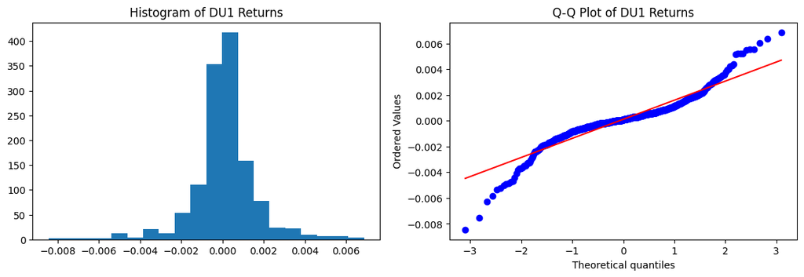

```
TU2 - Shapiro-Wilk Statistic: 0.925079345703125, p-value: 3.074380941904919e-18
The data for TU2 does not appear to be normally distributed according to Shapiro-Wilk test.
TU2 - D'Agostino's K^2 Statistic: 80.22060976984064, p-value: 3.8046606002297865e-18
The data for TU2 does not appear to be normally distributed according to D'Agostino's K^2 test.
```

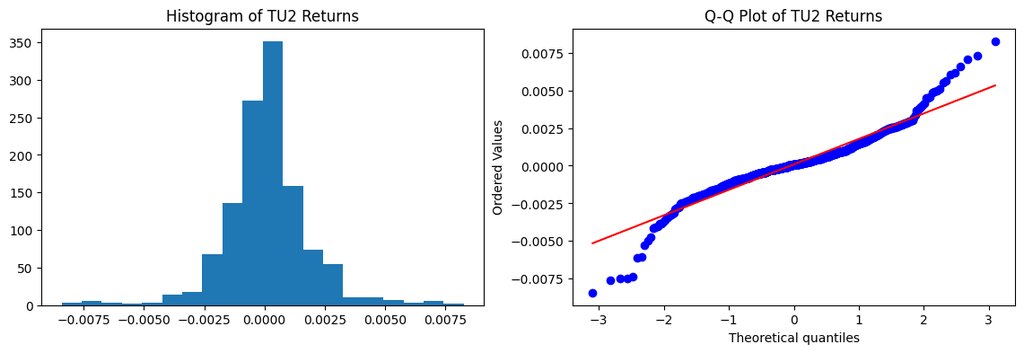

```python
# GAUSSIANITY STUDY

# Function to check Gaussianity for each future
def check_gaussianity(data):
    for column in data.columns:
        # Perform Shapiro-Wilk test
        stat_sw, p_sw = shapiro(data[column])
        print(f'{column} - Shapiro-Wilk Statistic: {stat_sw}, p-value: {p_sw}')
        if p_sw > 0.05:
            print(f'The data for {column} appears to be normally distributed according to Shapiro-Wilk test.')
        else:
            print(f'The data for {column} does not appear to be normally distributed according to Shapiro-Wilk test.')

        # Perform D'Agostino's K^2 test
        stat_k2, p_k2 = normaltest(data[column])
        print(f"{column} - D'Agostino's K^2 Statistic: {stat_k2}, p-value: {p_k2}")
        if p_k2 > 0.05:
            print(f"The data for {column} appears to be normally distributed according to D'Agostino's K^2 test.")
        else:
            print(f"The data for {column} does not appear to be normally distributed according to D'Agostino's K^2 test.")

        # Plot histogram and Q-Q plot
        plt.figure(figsize=(14, 4))
        plt.subplot(1, 2, 1)
        plt.hist(data[column], bins=20, density=True)
        plt.title(f'Histogram of {column} Returns')
        plt.subplot(1, 2, 2)
        probplot(data[column], dist='norm', plot=plt)
        plt.title(f'Q-Q Plot of {column} Returns')
        plt.show()

# Check Gaussianity of futures returns
check_gaussianity(returns_futures)
```

--> **None of the Futures appear to be Gaussian**

**Autocorrelation**

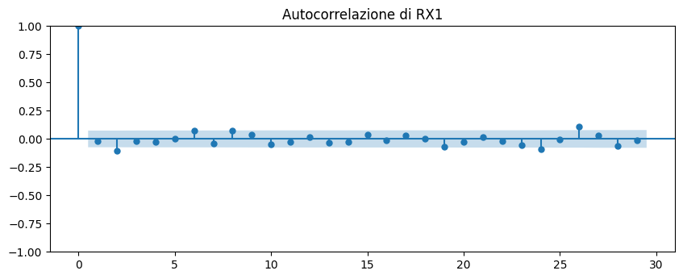

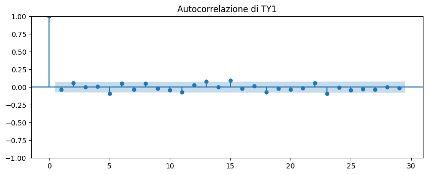

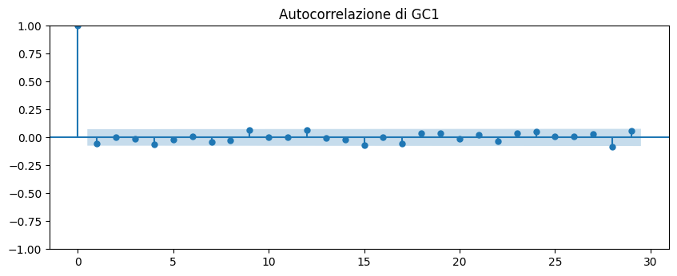

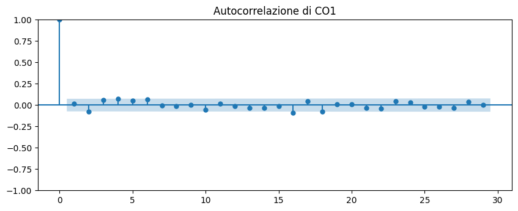

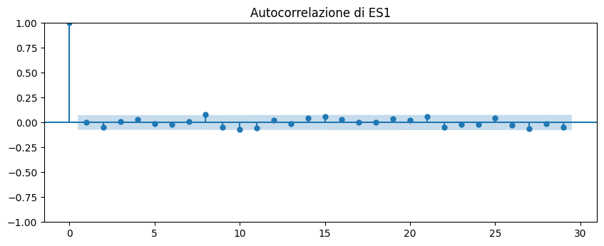

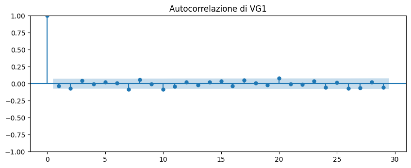

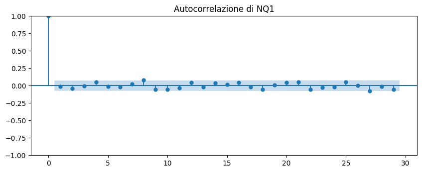

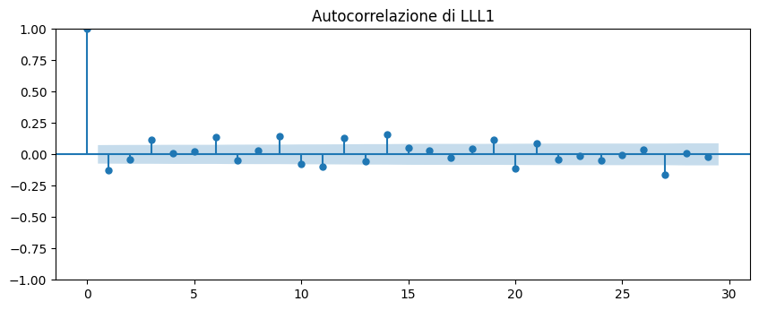

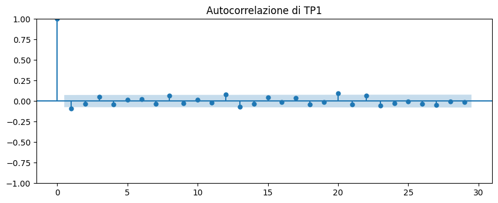

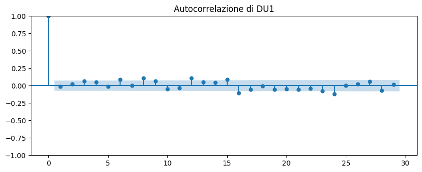

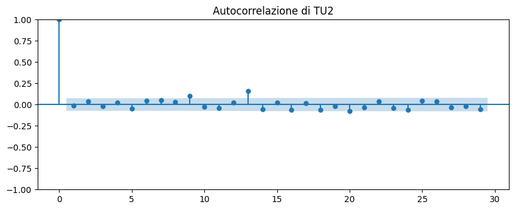

```python
# AUTOCORRELATION STUDY

plt.figure(figsize=(10, 8))

# Iterare su ciascun future e creare i grafici di autocorrelazione e autocorrelazione parziale
for future in returns_futures.columns:
    plt.figure(figsize=(10, 8))

    # Subplot per l'autocorrelazione
    plt.subplot(2, 1, 1)
    sm.graphics.tsa.plot_acf(returns_futures[future], ax=plt.gca())
    plt.title(f'Autocorrelazione di {future}')

    plt.show()
```

**Stationarity**